# Partial Identification

CML Week 10

2026-11-10

## Schedule

1. Design-based causal inference & Monte Carlo simulation
2. Covariate adjustment
3. Balancing weights
4. Double robustness, Double ML and TMLE
5. Heterogeneous Treatment Effects
6. HTE II: Neural Networks
7. Off-policy evaluation and optimization
8. Experimental design
9. Panel data and the new diff-in-diff
10. **Partial Identification**
11. Response adaptation
12. Interference

## Readings for Today

Foundational

- (Manski 1990): Nonparametric bounds on treatment effects

**Common**

- (Tamer 2010): Partial identification in econometrics

Presenter

- (Lee 2009): Training, wages, and sample selection: estimating sharp bounds on treatment effects
- (Yadlowsky et al. 2022): Bounds on the conditional and average treatment effect with unobserved confounding factors

## The promise and peril of causal inference

**So far this semester:** We’ve assumed strong identification conditions

- Randomization (experiments)
- Unconfoundedness (selection on observables)
- Parallel trends (difference-in-differences)

**These assumptions allow us to point identify causal effects**

**But what happens when these assumptions fail?**

- Unobserved confounding
- Lack of overlap in covariate distributions
- Missing outcome data
- Violations of SUTVA

**The traditional choice:** Make untestable assumptions or give up entirely

Is there a middle ground?

## The partial identification alternative

**Key insight from Manski (1990):** Even without point identification, data often restrict the range of possible treatment effects

**The approach:**

- Bound parameters rather than estimate them precisely
- Be honest about uncertainty while still being informative
- Ask: “What can we learn with minimal assumptions?”

**Manski’s “worst-case bounds”:** What can we say about treatment effects using only:

- The observed data
- The support of the outcome variable
- *No other assumptions*

**The answer:** Surprisingly much! The bounds may be wide, but they’re assumption-free.

# (Manski 1990)

## Setup: The missing data problem

**The estimand:** Average treatment effect

$$\tau = \mathbb{E}[Y(1) - Y(0)]$$

**The fundamental problem of causal inference:** We never observe both $Y_i(1)$ and $Y_i(0)$ for the same unit

**What we observe:**

$$Y_i = A_i Y_i(1) + (1 - A_i) Y_i(0)$$

where $A_i = 1$ if unit $i$ receives treatment, 0 otherwise

**This creates missing data on potential outcomes**

- For treated units: $Y_i(0)$ is missing
- For control units: $Y_i(1)$ is missing

**Point identification requires filling in the missing data** using assumptions (randomization, unconfoundedness, etc.)

## No-assumptions bounds: The logic

**Question:** What can we say about $\tau$ without any assumptions (or data)?

**Key observation:** For each unit, the treatment effect $Y_i(1) - Y_i(0)$ must lie in some range

**If the outcome has support $Y \in [y_L, y_U]$, then:**

$$Y_i(1) - Y_i(0) \in [y_L - y_U, y_U - y_L]$$

**Example:** If $Y$ is binary (0 or 1):

- Worst case for treated: $Y_i(1) = 0$ and $Y_i(0) = 1 \implies$ effect = $-1$
- Best case for treated: $Y_i(1) = 1$ and $Y_i(0) = 0 \implies$ effect = $+1$

**Averaging over the population gives bounds on $\tau$**

## No-assumptions bounds: The math

**For the treated group:**

$$\begin{aligned}
\mathbb{E}[Y(1) - Y(0) \mid D=1] &= \mathbb{E}[Y \mid D=1] - \mathbb{E}[Y(0) \mid D=1]\\
&= \text{observed} - \text{unobserved}
\end{aligned}$$

**Bound the unobserved quantity:** $\mathbb{E}[Y(0) \mid D=1] \in [y_L, y_U]$

**This gives bounds on ATT:**

$$\mathbb{E}[Y \mid D=1] - y_U \leq \mathbb{E}[Y(1) - Y(0) \mid D=1] \leq \mathbb{E}[Y \mid D=1] - y_L$$

**Similarly for the control group:**

$$y_L - \mathbb{E}[Y \mid D=0] \leq \mathbb{E}[Y(1) - Y(0) \mid D=0] \leq y_U - \mathbb{E}[Y \mid D=0]$$

**Bounds on ATE:** Weighted average of bounds on ATT and ATC

**Width of bounds:** Depends directly on the range of $Y$, i.e., $y_U - y_L$

## Tightening bounds with assumptions

**The tradeoff:** Bounds with no assumptions may be wide and uninformative

**Solution:** Add assumptions to tighten bounds

**Monotone Treatment Response (MTR):** Treatment weakly increases (or decreases) outcomes for everyone

$$Y_i(1) \geq Y_i(0) \quad \text{for all } i$$

**How MTR tightens bounds on ATT:**

- Without MTR: $\mathbb{E}[Y(0) \mid D=1] \in [y_L, y_U]$
- With MTR: $\mathbb{E}[Y(0) \mid D=1] \in [y_L, \mathbb{E}[Y \mid D=1]]$
- The upper bound shrinks from $y_U$ to the observed mean!

**General principle:** bounds = what we observe + assumptions about what we don’t observe

**The key question:** Are the additional assumptions credible?

## Connection to selection

**Observation:** The width of bounds reflects the strength of selection into treatment

$$\begin{aligned}
\mathbb{E}[Y(1) - Y(0) \mid D=1] = {} & \mathbb{E}[Y \mid D=1] -\mathbb{E}[Y \mid D=0]\\
& + \mathbb{E}[Y(0) \mid D=0]- \mathbb{E}[Y(0) \mid D=1]
\end{aligned}$$

**Selection bias:** $\mathbb{E}[Y(0) \mid D=0]- \mathbb{E}[Y(0) \mid D=1]$

**What this means:** Bounds express the possibility of selection bias

## Why bounds matter

**A fundamental tension in causal inference:**

- **Precise but wrong:** Point estimates with invalid assumptions
- **Honest but wide:** Bounds with minimal assumptions

**Which is better?**

Better to report $[−0.5, 0.8]$ honestly than $0.15$ (s.e. $0.08$) with false precision

**Bounds enable falsification without strong assumptions:**

- If the null effect (zero) lies outside the bounds, we can reject it
- If bounds include zero, we learn that no-assumptions approach cannot reject the null
- This is informative! It tells us we need stronger assumptions to draw conclusions

**Policy implications:**

- Bounds can rule out effects below a certain threshold
- Example: If lower bound on wage effect is $\$2$/hour, we know effect is at least that large

## Sharp bounds and extensions

**Definition:** Bounds are “sharp” if they are the tightest possible given the assumptions

**Manski’s no-assumptions bounds are sharp:** You cannot do better without adding assumptions

**The modern literature builds on this foundation in several ways:**

1. **Additional shape restrictions:** Monotonicity, convexity, smoothness
2. **Parametric/semiparametric models:** Impose structure on potential outcomes
3. **Additional data sources:** Instrumental variables, proxy variables, negative controls
4. **Machine learning:** Estimate bounds flexibly without parametric assumptions

**Key principle:** Every tightening requires a justifiable assumption

**Your classmates’ presentations:** Show how modern methods tighten bounds while maintaining credibility

# (Aronow, Green, and Lee 2014)

## The variance is partially identified

Week 1: under complete randomization,

$$\text{Var}_A[\hat{\tau} \mid \mathcal{S}] = \frac{s_{Y(1)}^2}{N_1} + \frac{s_{Y(0)}^2}{N_0} - \frac{s_{Y(1)}^2 + s_{Y(0)}^2 - 2\hlred{s_{Y(1),Y(0)}}}{N}$$

- Randomization identifies each marginal: the treated are a random sample of the $Y_i(1)$, the controls of the $Y_i(0)$
- The covariance needs the joint: which $Y_i(0)$ goes with which $Y_i(1)$
- Manski’s missing-data problem again: bound the unidentified piece by what the marginals allow

**Two upper bounds on the variance:**

- Neyman: $s_\tau^2 \geq 0$, i.e. $s_{Y(1),Y(0)} \leq (s_{Y(1)}^2 + s_{Y(0)}^2)/2$
- Cauchy–Schwarz: $s_{Y(1),Y(0)} \leq s_{Y(1)} s_{Y(0)}$, so $s_\tau^2 \geq (s_{Y(1)} - s_{Y(0)})^2$
- Neither is sharp: correlation $1$ is only attainable if the marginals are the same up to an increasing affine map

## The rearrangement inequality

For $a_{(1)} \leq \dots \leq a_{(N)}$, $b_{(1)} \leq \dots \leq b_{(N)}$ and any permutation $\sigma$:

$$\sum_i a_{(i)} b_{(N+1-i)} \;\leq\; \sum_i a_{(i)} b_{\sigma(i)} \;\leq\; \sum_i a_{(i)} b_{(i)}$$

The covariance is largest when sorted together, smallest when sorted against each other. Same marginals, three pairings:

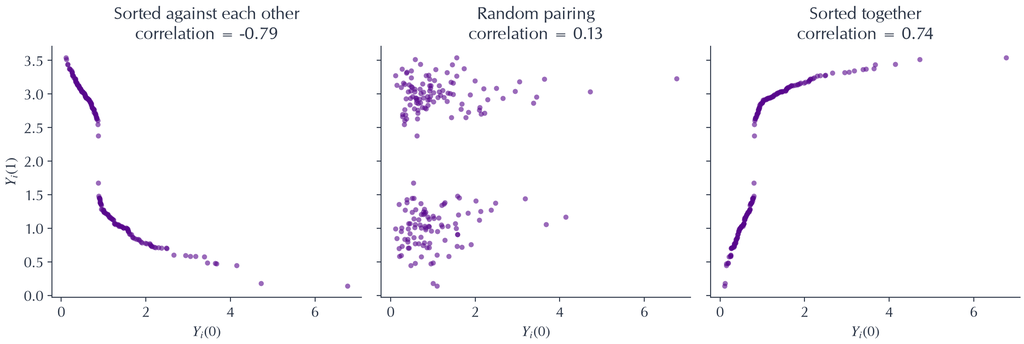

## Sharp bounds on the variance

In the population, sorting means pairing quantiles by rank. With $F_a$ the distribution of $Y_i(a)$:

$$\begin{aligned}
\sigma^H &= \textstyle\int_0^1 F_1^{-1}(u)\,F_0^{-1}(u)\,du - \mu_1\mu_0\\
\sigma^L &= \textstyle\int_0^1 F_1^{-1}(u)\,F_0^{-1}(1-u)\,du - \mu_1\mu_0
\end{aligned}$$

- Substituting these for the covariance gives $[V^L, V^H]$, the sharp identified set
- Estimation: each arm is a random sample from $F_a$, so plug in its empirical quantiles
- Neyman $\geq$ Cauchy–Schwarz $\geq V^H \geq$ true variance

## How much tighter?

$Y_i(0)$ right-skewed, $Y_i(1)$ bimodal, $N_1 = N_0 = 100$; the truth is the random pairing

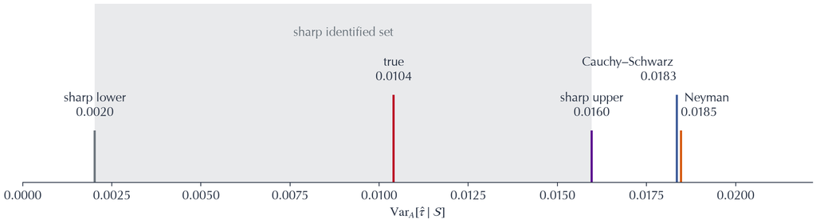

- Cauchy–Schwarz barely improves on Neyman: $s_{Y(1)} \approx s_{Y(0)}$
- The sharp upper bound is 13% smaller: the marginals’ shapes, not just their spreads, rule out perfect correlation

# (Imbens and Manski 2004)

## Hypothesis testing with bounds

**The setup:** You’ve estimated bounds $[\hat{\theta}_L, \hat{\theta}_U]$ with standard errors $\text{se}(\hat{\theta}_L)$ and $\text{se}(\hat{\theta}_U)$

**How to construct a $(1-\alpha)$ confidence interval?**

**Imbens and Manski (2004):** Use one-sided tests at each endpoint!

$$\left[\hat{\theta}_L - z_{\alpha} \cdot \text{se}(\hat{\theta}_L), \quad \hat{\theta}_U + z_{\alpha} \cdot \text{se}(\hat{\theta}_U)\right]$$

**Why $z_\alpha$ instead of $z_{\alpha/2}$?**

- Lower bound: only care if true $\theta_L$ is *below* $\hat{\theta}_L$ (one-sided)
- Upper bound: only care if true $\theta_U$ is *above* $\hat{\theta}_U$ (one-sided)
- This is less overly conservative!

**Refinement:** Can use data-dependent critical value to improve finite-sample behavior

**For hypothesis testing $H_0: \theta = \theta_0$:**

- Reject if $\theta_0$ lies outside the confidence interval

# Synthesis

## Partial identification in modern causal ML

**Yadlowsky et al. (2022):** Unobserved confounding in observational studies

- Bound the strength of confounding via sensitivity parameters

**Samii, Wang, and Zhou (2026):** Endogenous sample selection (missing outcomes)

- Stochastic dominance restrictions on outcome distributions

**Khan, Saveski, and Ugander (2024):** Off-policy evaluation when new policy treats where old policy never did

- Smoothness/Lipschitz continuity of the outcome function

**Common theme:** Honest epistemic uncertainty by carefully adding assumptions

# References

Aronow, Peter M, Donald P Green, and Donald K K Lee. 2014. “Sharp Bounds on the Variance in Randomized Experiments.” *Annals of Statistics* 42 (3): 850–71.

Imbens, Guido W, and Charles F Manski. 2004. “Confidence Intervals for Partially Identified Parameters.” *Econometrica* 72 (6): 1845–57.

Khan, Saad, Martin Saveski, and Johan Ugander. 2024. “Off-Policy Evaluation Beyond Overlap: Partial Identification Through Smoothness.” In *Proceedings of the 41st International Conference on Machine Learning*.

Lee, David S. 2009. “Training, Wages, and Sample Selection: Estimating Sharp Bounds on Treatment Effects.” *Review of Economic Studies* 76 (3): 1071–1102.

Manski, Charles F. 1990. “Nonparametric Bounds on Treatment Effects.” *American Economic Review* 80 (2): 319–23.

Samii, Cyrus, Ye Wang, and Junlong Zhou. 2026. “Generalizing Trimming Bounds for Endogenously Missing Outcome Data Using Random Forests.” *Political Analysis* 34 (1): 23–37.

Tamer, Elie. 2010. “Partial Identification in Econometrics.” *Annual Review of Economics* 2 (1): 167–95.

Yadlowsky, Steve, Hongseok Namkoong, Sanjay Basu, John Duchi, and Lu Tian. 2022. “Bounds on the Conditional and Average Treatment Effect with Unobserved Confounding Factors.” *Annals of Statistics* 50 (5): 2587–2615.